# Crime in Los Angeles, California

Tiffani Pham (tpham5@uw.edu), Aswin Sundar (aswinsun@uw.edu), Sonic Yao (sjy9@uw.edu), Garrett Ruth (gsr19@uw.edu)

Winter 2022

## Abstract

Our main question is: What are the most common crimes that occur in Los Angeles, California, and why? This question is important because the types of crimes vary, and knowing what kind of crimes are more prominent in the city, it will help people address the issue and to keep the crimes limited. To address the question, we will look into the Los Angeles crime data, which includes several different factors, such as, dates and times occurred, area of occurrence, and we plan to not only look at the occurrences but to also explore why these crimes are happening.

## Keywords

crime; los angeles; california; crime purpose; crimes reported

## Introduction

Crime rates are continuing to increase, specifically in the well-known city of Los Angeles, California. For this project, we are diving into Los Angeles crime data from 2020 up until now. Our main objective is to extract from the dataset which crimes are the most common and likely to happen while also looking into why these crimes occur. With the uprise in crimes, it is important that we are helping out the key stakeholders to be aware of these crimes in order to prevent them from occurring and how to deal with them. We want to help create a safer community in Los Angeles, whereas there is a population of almost 4 million people, with many tourists going in and out of the city as well.

## Design Situation

### Framing Crime

Our topic is focused around the crime of a single mega-city which incorporates many aspects of society including, racism, poverty, abuse of power, and others. Here we are trying to categorize crime data based on their possible root causes to identify the biggest societal issues facing Los Angeles.

### Human Values

Human values are deeply related to our issues as the issues facing the people are what leads to the crimes committed. Specifically how the issues that affect the people of Los Angeles have a role in the types of crime committed and what situations lead to the need to break the law.

### Stakeholders

The LA police force and the local government are the most benefitted by our project as it can lead discussions and bill creation in order to address the problems highlighted in this project. All of this would also benefit the people of Los Angeles as the societal issues facing them can be more easily identified which hopefully would make it easier to solve them.

### Benefits and Harms

Without actual people to filter through this data the data can be used to commit more police resources to underprivileged areas that need financial assistance to solve the crime issues and instead would be harmed by more police presence. Although, with the categories created we can distinguish these types of crimes by need instead of violent crimes.

## Research Questions

1. What are the most common crimes that occur in Los Angeles, CA?
2. Why do these crimes occur?
3. Which months of the year have the most crimes that were reported?
4. Which area in area in Los Angeles has the most crimes?

These questions are important to address because there is an increase in crime rates. By knowing the answers to these questions, police, citizens, society, etc. can predict and be aware of what crimes are likely to happen and prevent them from happening. It is important that as a society, we are keeping people as safe as possible and ensure that people are being ethical in their actions. These questions being answered will further community relations, better resource allocation and budget formations, and many more.

## The Dataset

The dataset for crimes in LA, although having only 1 file, is quite complex. There are more than 250,000 observations and 28 features. Each observation represents a single case. The 28 attributes provide information on the record, victim, crime, location, and time. Features that will be important in our investigation includes the crime code, which indicates the severity of the crime, the area and area name and information about the victims. General information such as age, sex, and descent are presented in the data, however, no information on the offender is given.

This Public Safety Data is released by the LAPD which comes with a certain credibility. We obtained the data from Kaggle, which is community based. This dataset was updated 7 months ago and uploaded by a Kaggle contributor. As this data is transcribed from the original crime reports from the LAPD, it is likely that the data collection is government funded. The data allows for crime mapping which highlights areas that are more prone to crime and this information is made available to the public in the hopes that they will make decisions to be safer.

While the data may lead us to believe that it includes all crimes in Los Angeles, it only includes crimes with records in the LAPD’s database. Unreported crime is potentially missing from the data and can create a large gap between the models created using this data and the real world. It is possible that victims choose to not report crimes due to various reasons and crimes such as rape often go unreported. This gap in one type of crime has the power to alter the public’s view of the world around them. Journalists or news that use this data for their statistics in their reports might be using accurate data, but the data is not necessarily an accurate representation of the population. Consumers of the articles could potentially be indirectly impacted by this data. Another important aspect of visualizing crime rates is the ratio between crime and population density in an area. Without context, areas may seem safe or unsafe just based on simple visualizations such as a basic crime map. Although it provides certain useful information, it is not all there is to it.

## Expected Implications

Some possible implications for **designers** specifically would include maybe designing new products/apps based on the answers to the research questions that can track crime locations on average so that the general population can stay safer. Apps and products like these can help to make the city and the general population much safer. Some possible implications for **policymakers** would be to make new policies based on the answers to the research questions such as marking several locations in LA as crime-prominent and allocating resources much better to make the city safer. These new policies can have long lasting effects on the city and can therefore make it much safer. Some possible implications for **technologists** would maybe new technologies that can help people understand the reasons behind the crimes and convince people to not engage in such crimes. These new technologies can help people be much safer by addressing the problem of crimes at the source and stopping it at the source as well.

## Limitations

Some limitations that we may have to face include the **lack of data** from before 2020 as we only have data from 2020 on. This would be the major limitation that we would need to address due to it being the large amount of data that we don’t have access to. Another limitation we would have to face would be the **lack of specificity** in the crime location data as the data provided is only provided to the nearest hundredth block. This is done in order to maintain privacy. Another limitation in the crime location data would be **the missing data** for some crimes noted by the address of (0°, 0°). One final limitation that we would need to face would be the **inaccuracies** within the data since the data is transcribed from original crime reports that are typed on paper.

## Summary

The total number of crimes reported in 2020 and 2021 is 196772 and 79812 respectively, making the combined total of 276584. The area with the most number of crimes is 77th Street and the proportion of crimes without involving weapons is 0.63.

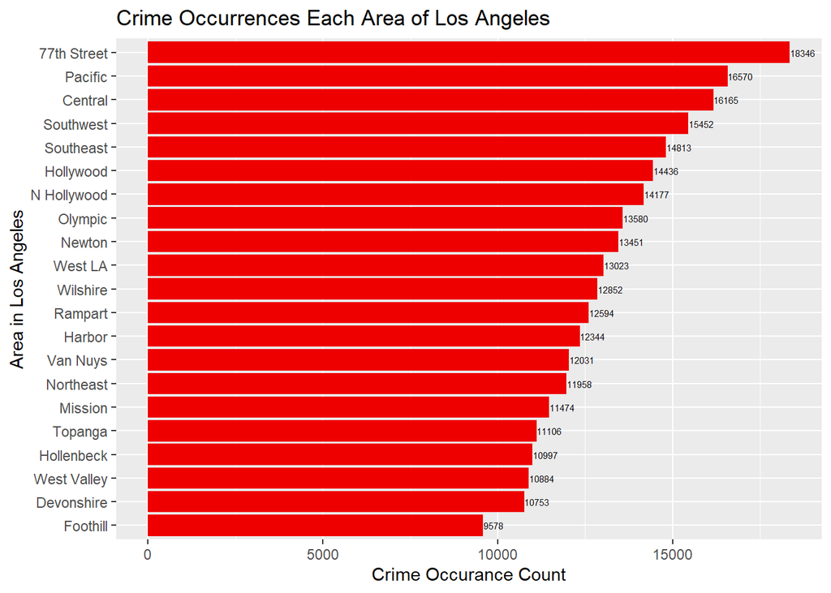

The question we are trying to answer with this chart is: Which area in Los Angeles has the most crimes that were reported? The purpose of this chart is to show how many crimes were reported in each of the different areas of Los Angeles. We put the areas in order from area with most occurrences to least occurrences. By looking at the different areas, people are able to see where they are most safe in Los Angeles, and where there needs to be more regulation and awareness. From this chart, we can see that the area with the most crimes is 77th Street (18,346 observations), whereas the area with the least crimes is Foothill (9,578 observations). The top 3 areas that had the most crime occurrences were 77th Street, Pacific, and Central.

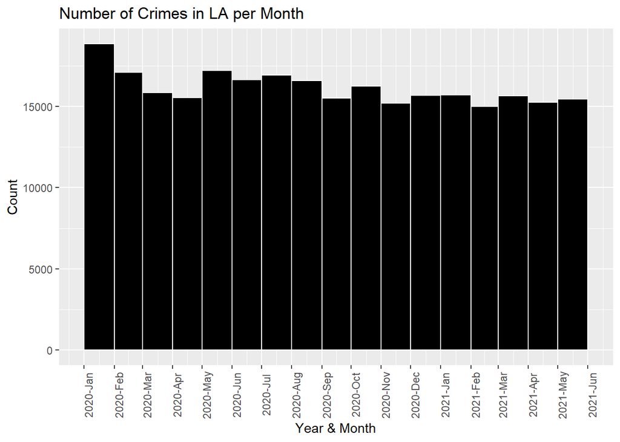

This chart illustrates how the crime rate varies each month to help identify if there is a time frame which crimes are more likely to occur. Although the chart shows a larger number of crimes in January of 2020, there is no clear trend or pattern to suggest crime rate differences by month.

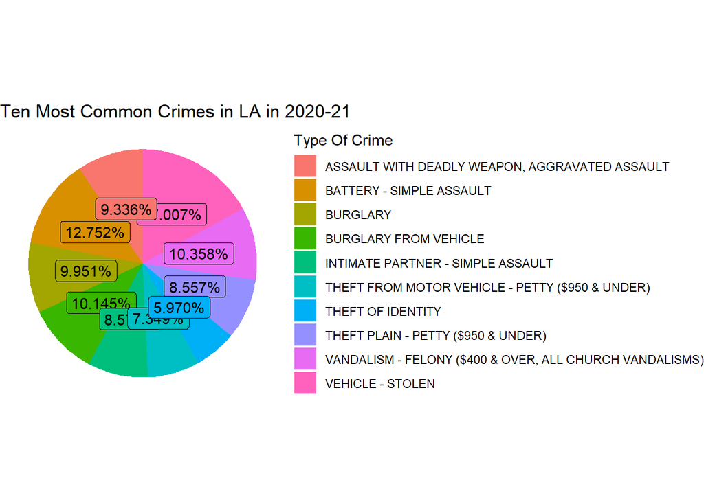

The frequency of each unique crime

| Crm.Cd.Desc | count |
| --- | --- |
| ARSON | 949 |
| ASSAULT WITH DEADLY WEAPON ON POLICE OFFICER | 487 |
| ASSAULT WITH DEADLY WEAPON, AGGRAVATED ASSAULT | 16493 |
| ATTEMPTED ROBBERY | 1584 |
| BATTERY - SIMPLE ASSAULT | 22528 |
| BATTERY ON A FIREFIGHTER | 68 |
| BATTERY POLICE (SIMPLE) | 907 |
| BATTERY WITH SEXUAL CONTACT | 1176 |
| BEASTIALITY, CRIME AGAINST NATURE SEXUAL ASSLT WITH ANIM | 1 |
| BIKE - ATTEMPTED STOLEN | 3 |
| BIKE - STOLEN | 2882 |
| BOAT - STOLEN | 39 |
| BOMB SCARE | 113 |
| BRANDISH WEAPON | 4493 |
| BRIBERY | 2 |
| BUNCO, ATTEMPT | 111 |
| BUNCO, GRAND THEFT | 1564 |
| BUNCO, PETTY THEFT | 712 |
| BURGLARY | 17580 |
| BURGLARY FROM VEHICLE | 17922 |
| BURGLARY FROM VEHICLE, ATTEMPTED | 229 |
| BURGLARY, ATTEMPTED | 1259 |
| CHILD ABANDONMENT | 5 |
| CHILD ABUSE (PHYSICAL) - AGGRAVATED ASSAULT | 195 |
| CHILD ABUSE (PHYSICAL) - SIMPLE ASSAULT | 1028 |
| CHILD ANNOYING (17YRS & UNDER) | 268 |
| CHILD NEGLECT (SEE 300 W.I.C.) | 377 |
| CHILD PORNOGRAPHY | 69 |
| CHILD STEALING | 139 |
| CONSPIRACY | 8 |

[output cut: 102 more lines]

This table shows the frequency of all unique crimes reported in 2020-2021. It provides a detailed view of the scale and types of crimes occurred. The information here is similar to the pie chart presented above, but reveals crimes which were not frequent enough to be presented in the pie chart.

Total frequency of each crime in a district

|  | 77th Street | Central | Devonshire | Foothill | Harbor | Hollenbeck | Hollywood | Mission | N Hollywood | Newton | Northeast | Olympic | Pacific | Rampart | Southeast | Southwest | Topanga | Van Nuys | West LA | West Valley | Wilshire |
| --- | --- | --- | --- | --- | --- | --- | --- | --- | --- | --- | --- | --- | --- | --- | --- | --- | --- | --- | --- | --- | --- |
| ARSON | 80 | 86 | 18 | 19 | 34 | 32 | 45 | 42 | 48 | 68 | 32 | 62 | 54 | 55 | 63 | 60 | 13 | 34 | 22 | 26 | 56 |
| ASSAULT WITH DEADLY WEAPON ON POLICE OFFICER | 32 | 115 | 3 | 25 | 3 | 8 | 30 | 9 | 15 | 16 | 11 | 6 | 15 | 18 | 27 | 20 | 16 | 5 | 1 | 13 | 99 |
| ASSAULT WITH DEADLY WEAPON, AGGRAVATED ASSAULT | 2040 | 1147 | 333 | 515 | 737 | 774 | 799 | 647 | 582 | 1155 | 494 | 711 | 719 | 950 | 1659 | 1091 | 432 | 468 | 231 | 486 | 523 |
| ATTEMPTED ROBBERY | 170 | 141 | 23 | 31 | 61 | 54 | 101 | 44 | 50 | 98 | 69 | 101 | 51 | 111 | 134 | 113 | 45 | 39 | 43 | 45 | 60 |
| BATTERY - SIMPLE ASSAULT | 1382 | 1875 | 738 | 773 | 1028 | 1030 | 1268 | 779 | 1006 | 1196 | 751 | 1311 | 1051 | 1265 | 1237 | 1474 | 839 | 902 | 936 | 725 | 962 |
| BATTERY ON A FIREFIGHTER | 4 | 8 | 0 | 2 | 3 | 2 | 6 | 2 | 2 | 0 | 6 | 3 | 9 | 4 | 1 | 2 | 1 | 1 | 5 | 2 | 5 |
| BATTERY POLICE (SIMPLE) | 99 | 106 | 21 | 39 | 25 | 28 | 91 | 24 | 41 | 29 | 18 | 43 | 48 | 26 | 81 | 56 | 15 | 30 | 13 | 18 | 56 |
| BATTERY WITH SEXUAL CONTACT | 41 | 115 | 40 | 34 | 33 | 30 | 84 | 43 | 51 | 49 | 34 | 71 | 92 | 67 | 36 | 73 | 51 | 44 | 85 | 44 | 59 |
| BEASTIALITY, CRIME AGAINST NATURE SEXUAL ASSLT WITH ANIM | 0 | 0 | 0 | 0 | 0 | 0 | 0 | 0 | 0 | 0 | 0 | 0 | 0 | 0 | 0 | 0 | 0 | 0 | 0 | 1 | 0 |
| BIKE - ATTEMPTED STOLEN | 0 | 2 | 0 | 0 | 0 | 0 | 0 | 0 | 0 | 0 | 1 | 0 | 0 | 0 | 0 | 0 | 0 | 0 | 0 | 0 | 0 |
| BIKE - STOLEN | 12 | 309 | 38 | 14 | 42 | 22 | 166 | 42 | 130 | 21 | 130 | 149 | 612 | 114 | 11 | 254 | 35 | 117 | 466 | 76 | 122 |
| BOAT - STOLEN | 1 | 0 | 3 | 9 | 8 | 0 | 0 | 5 | 0 | 1 | 1 | 0 | 2 | 0 | 3 | 1 | 0 | 3 | 1 | 0 | 1 |
| BOMB SCARE | 2 | 22 | 1 | 2 | 3 | 1 | 11 | 4 | 0 | 0 | 4 | 6 | 24 | 2 | 0 | 3 | 6 | 6 | 8 | 3 | 5 |
| BRANDISH WEAPON | 476 | 305 | 137 | 159 | 204 | 185 | 279 | 190 | 179 | 270 | 154 | 269 | 164 | 226 | 295 | 358 | 113 | 133 | 68 | 158 | 171 |
| BRIBERY | 0 | 0 | 0 | 0 | 0 | 0 | 1 | 0 | 0 | 0 | 0 | 0 | 0 | 0 | 0 | 0 | 0 | 1 | 0 | 0 | 0 |
| BUNCO, ATTEMPT | 6 | 5 | 1 | 2 | 18 | 0 | 4 | 3 | 5 | 2 | 5 | 2 | 4 | 18 | 12 | 10 | 4 | 4 | 4 | 2 | 0 |
| BUNCO, GRAND THEFT | 57 | 54 | 85 | 60 | 65 | 69 | 97 | 57 | 79 | 31 | 71 | 88 | 108 | 64 | 17 | 94 | 93 | 72 | 141 | 80 | 82 |
| BUNCO, PETTY THEFT | 30 | 33 | 29 | 40 | 19 | 26 | 63 | 32 | 29 | 25 | 28 | 47 | 25 | 20 | 32 | 47 | 38 | 25 | 56 | 31 | 37 |
| BURGLARY | 687 | 786 | 836 | 572 | 761 | 524 | 866 | 572 | 1097 | 751 | 857 | 909 | 1366 | 557 | 492 | 603 | 944 | 798 | 1484 | 859 | 1259 |
| BURGLARY FROM VEHICLE | 709 | 1665 | 794 | 546 | 560 | 432 | 1075 | 596 | 1175 | 650 | 913 | 857 | 1220 | 837 | 583 | 708 | 772 | 970 | 1182 | 754 | 924 |
| BURGLARY FROM VEHICLE, ATTEMPTED | 24 | 7 | 7 | 6 | 13 | 9 | 5 | 3 | 9 | 14 | 6 | 17 | 17 | 14 | 19 | 25 | 12 | 7 | 6 | 5 | 4 |
| BURGLARY, ATTEMPTED | 66 | 40 | 77 | 45 | 57 | 52 | 51 | 54 | 54 | 50 | 59 | 62 | 101 | 38 | 40 | 68 | 63 | 55 | 89 | 78 | 60 |
| CHILD ABANDONMENT | 2 | 0 | 0 | 0 | 0 | 0 | 0 | 0 | 0 | 2 | 0 | 0 | 0 | 1 | 0 | 0 | 0 | 0 | 0 | 0 | 0 |
| CHILD ABUSE (PHYSICAL) - AGGRAVATED ASSAULT | 22 | 3 | 5 | 5 | 13 | 6 | 6 | 11 | 5 | 10 | 8 | 6 | 4 | 5 | 45 | 12 | 5 | 3 | 3 | 11 | 7 |
| CHILD ABUSE (PHYSICAL) - SIMPLE ASSAULT | 85 | 12 | 52 | 63 | 94 | 51 | 13 | 106 | 47 | 42 | 32 | 33 | 33 | 28 | 103 | 94 | 21 | 43 | 9 | 31 | 36 |
| CHILD ANNOYING (17YRS & UNDER) | 14 | 7 | 16 | 15 | 18 | 16 | 3 | 14 | 16 | 18 | 10 | 8 | 13 | 15 | 16 | 14 | 10 | 15 | 7 | 14 | 9 |
| CHILD NEGLECT (SEE 300 W.I.C.) | 44 | 13 | 13 | 26 | 14 | 14 | 12 | 34 | 14 | 13 | 11 | 17 | 11 | 9 | 19 | 33 | 8 | 20 | 9 | 24 | 19 |
| CHILD PORNOGRAPHY | 7 | 0 | 1 | 2 | 0 | 7 | 4 | 4 | 2 | 3 | 8 | 0 | 4 | 3 | 2 | 7 | 2 | 4 | 1 | 3 | 5 |
| CHILD STEALING | 33 | 1 | 3 | 3 | 8 | 4 | 6 | 4 | 3 | 4 | 4 | 1 | 2 | 5 | 16 | 10 | 6 | 11 | 0 | 9 | 6 |
| CONSPIRACY | 0 | 0 | 1 | 0 | 0 | 0 | 0 | 1 | 0 | 0 | 0 | 0 | 0 | 1 | 1 | 0 | 1 | 0 | 0 | 2 | 1 |

[output cut: 102 more lines]

The frequency of violent crimes in a district

|  | 77th Street | Central | Devonshire | Foothill | Harbor | Hollenbeck | Hollywood | Mission | N Hollywood | Newton | Northeast | Olympic | Pacific | Rampart | Southeast | Southwest | Topanga | Van Nuys | West LA | West Valley | Wilshire |
| --- | --- | --- | --- | --- | --- | --- | --- | --- | --- | --- | --- | --- | --- | --- | --- | --- | --- | --- | --- | --- | --- |
| ARSON | 27 | 31 | 3 | 3 | 7 | 3 | 19 | 11 | 7 | 26 | 15 | 18 | 15 | 20 | 20 | 11 | 1 | 5 | 5 | 2 | 22 |
| ASSAULT WITH DEADLY WEAPON ON POLICE OFFICER | 32 | 115 | 3 | 25 | 3 | 8 | 30 | 9 | 15 | 16 | 11 | 6 | 15 | 18 | 27 | 20 | 16 | 5 | 1 | 13 | 99 |
| ASSAULT WITH DEADLY WEAPON, AGGRAVATED ASSAULT | 2040 | 1147 | 333 | 515 | 737 | 774 | 799 | 647 | 582 | 1155 | 494 | 711 | 719 | 950 | 1659 | 1091 | 432 | 468 | 231 | 486 | 523 |
| ATTEMPTED ROBBERY | 170 | 141 | 23 | 31 | 61 | 54 | 101 | 44 | 50 | 98 | 69 | 101 | 51 | 111 | 134 | 113 | 45 | 39 | 43 | 45 | 60 |
| BATTERY - SIMPLE ASSAULT | 1382 | 1875 | 738 | 773 | 1028 | 1030 | 1268 | 779 | 1006 | 1196 | 751 | 1311 | 1051 | 1265 | 1237 | 1474 | 839 | 902 | 936 | 725 | 962 |
| BATTERY ON A FIREFIGHTER | 4 | 8 | 0 | 2 | 3 | 2 | 6 | 2 | 2 | 0 | 6 | 3 | 9 | 4 | 1 | 2 | 1 | 1 | 5 | 2 | 5 |
| BATTERY POLICE (SIMPLE) | 99 | 106 | 21 | 39 | 25 | 28 | 91 | 24 | 41 | 29 | 18 | 43 | 48 | 26 | 81 | 56 | 15 | 30 | 13 | 18 | 56 |
| BATTERY WITH SEXUAL CONTACT | 41 | 115 | 40 | 34 | 33 | 30 | 84 | 43 | 51 | 49 | 34 | 71 | 92 | 67 | 36 | 73 | 51 | 44 | 85 | 44 | 59 |
| BEASTIALITY, CRIME AGAINST NATURE SEXUAL ASSLT WITH ANIM | 0 | 0 | 0 | 0 | 0 | 0 | 0 | 0 | 0 | 0 | 0 | 0 | 0 | 0 | 0 | 0 | 0 | 0 | 0 | 1 | 0 |
| BIKE - STOLEN | 0 | 6 | 0 | 0 | 0 | 0 | 1 | 0 | 0 | 1 | 1 | 2 | 10 | 2 | 1 | 1 | 0 | 2 | 3 | 1 | 0 |
| BOMB SCARE | 2 | 22 | 1 | 2 | 3 | 1 | 11 | 4 | 0 | 0 | 4 | 6 | 24 | 2 | 0 | 3 | 6 | 6 | 8 | 3 | 5 |
| BRANDISH WEAPON | 476 | 305 | 137 | 159 | 204 | 185 | 279 | 190 | 179 | 270 | 154 | 269 | 164 | 226 | 295 | 358 | 113 | 133 | 68 | 158 | 171 |
| BUNCO, ATTEMPT | 0 | 1 | 0 | 0 | 0 | 0 | 0 | 0 | 0 | 0 | 0 | 0 | 0 | 0 | 0 | 0 | 0 | 0 | 0 | 0 | 0 |
| BUNCO, GRAND THEFT | 0 | 2 | 0 | 0 | 1 | 1 | 0 | 1 | 0 | 2 | 1 | 1 | 1 | 0 | 0 | 0 | 0 | 0 | 1 | 0 | 0 |
| BUNCO, PETTY THEFT | 0 | 0 | 1 | 0 | 0 | 0 | 1 | 0 | 0 | 0 | 0 | 0 | 0 | 0 | 0 | 1 | 0 | 0 | 0 | 0 | 0 |
| BURGLARY | 28 | 204 | 140 | 92 | 7 | 18 | 264 | 9 | 29 | 16 | 155 | 65 | 391 | 46 | 203 | 27 | 89 | 82 | 176 | 17 | 41 |
| BURGLARY FROM VEHICLE | 17 | 161 | 62 | 66 | 0 | 3 | 143 | 11 | 10 | 9 | 101 | 10 | 246 | 32 | 115 | 12 | 28 | 47 | 72 | 7 | 8 |
| BURGLARY FROM VEHICLE, ATTEMPTED | 0 | 2 | 1 | 0 | 0 | 0 | 1 | 0 | 0 | 1 | 0 | 3 | 4 | 1 | 7 | 1 | 2 | 1 | 1 | 0 | 0 |
| BURGLARY, ATTEMPTED | 7 | 16 | 18 | 17 | 0 | 2 | 22 | 1 | 2 | 2 | 15 | 7 | 21 | 12 | 19 | 6 | 8 | 5 | 6 | 2 | 2 |
| CHILD ABUSE (PHYSICAL) - AGGRAVATED ASSAULT | 22 | 3 | 5 | 5 | 13 | 6 | 6 | 11 | 5 | 10 | 8 | 6 | 4 | 5 | 45 | 12 | 5 | 3 | 3 | 11 | 7 |
| CHILD ABUSE (PHYSICAL) - SIMPLE ASSAULT | 85 | 12 | 52 | 59 | 94 | 51 | 13 | 106 | 47 | 42 | 32 | 33 | 33 | 28 | 103 | 94 | 21 | 43 | 9 | 31 | 35 |
| CHILD ANNOYING (17YRS & UNDER) | 5 | 2 | 2 | 2 | 3 | 3 | 1 | 2 | 4 | 4 | 5 | 4 | 0 | 7 | 4 | 3 | 3 | 1 | 1 | 3 | 2 |
| CHILD NEGLECT (SEE 300 W.I.C.) | 13 | 3 | 0 | 7 | 2 | 0 | 1 | 2 | 1 | 4 | 1 | 1 | 0 | 1 | 3 | 5 | 2 | 3 | 1 | 6 | 2 |
| CHILD STEALING | 4 | 0 | 0 | 0 | 0 | 0 | 0 | 0 | 0 | 0 | 0 | 1 | 0 | 0 | 0 | 0 | 0 | 1 | 0 | 0 | 0 |
| CONSPIRACY | 0 | 0 | 0 | 0 | 0 | 0 | 0 | 0 | 0 | 0 | 0 | 0 | 0 | 0 | 0 | 0 | 1 | 0 | 0 | 0 | 0 |
| CONTEMPT OF COURT | 18 | 0 | 0 | 2 | 0 | 1 | 0 | 0 | 8 | 1 | 0 | 0 | 0 | 1 | 8 | 0 | 0 | 1 | 0 | 1 | 0 |
| CRIMINAL HOMICIDE | 74 | 30 | 3 | 13 | 31 | 46 | 10 | 12 | 13 | 45 | 19 | 21 | 8 | 31 | 62 | 25 | 7 | 12 | 4 | 12 | 15 |
| CRIMINAL THREATS - NO WEAPON DISPLAYED | 453 | 340 | 206 | 170 | 291 | 231 | 375 | 234 | 225 | 241 | 253 | 253 | 270 | 263 | 434 | 402 | 207 | 202 | 241 | 258 | 302 |
| CRM AGNST CHLD (13 OR UNDER) (14-15 & SUSP 10 YRS OLDER) | 57 | 8 | 18 | 14 | 22 | 22 | 13 | 34 | 16 | 40 | 20 | 37 | 14 | 27 | 24 | 33 | 19 | 23 | 5 | 15 | 7 |
| CRUELTY TO ANIMALS | 6 | 2 | 1 | 1 | 3 | 2 | 5 | 2 | 0 | 2 | 2 | 1 | 1 | 2 | 0 | 2 | 1 | 0 | 2 | 2 | 1 |

[output cut: 74 more lines]

These tables help reveal the areas where Violent crime is persistent compared to non-violent crimes showing where police presence could help save lives compared to areas mostly consisting of non-violent crime where police presence would likely only save property from being stolen in that area and would just drive people to steal from other areas.

## References

1. Los Angeles Police Department. *Los Angeles Crime Data 2020-present.* (Crime_Data_from_2020_to_Present). Los Angeles, CA: Los Angeles Police Department, 2020. (https://www.waldenu.edu/online-bachelors-programs/bs-in-criminal-justice/resource/why-national-crime-statistics-are-important).
2. “Officers Shoot Person Armed With Knife in Pacoima.” NCS Los Angeles, 1 Feb. 2022.
3. United States, Congress, Census Bureau. Quick Facts, Los Angeles.
4. Winton, Richard. “Hate Crimes in L.A. and Other U.S. Cities Jump to Levels Not Seen in Decades, Study Finds.” Los Angeles Times, 1 Feb. 2022.